# Neotoma’s Floridian Paleoecological Records

Nick Hoffman

September 21, 2023

## Introduction

This page will use the R package Neotoma2 and the [Neotoma API](https://api.neotomadb.org/api-docs/#/Contact%20metadata/get_v2_0_data_sites__siteid__contacts) to briefly survey paleoecological records from the Florida region held by the Neotoma Paleoecology Database. If you would like to explore these records or other Neotoma data further, we are happy to help with that, so please reach out! This page was designed for use by scientists at the Seminole Tribe of Florida THPO.

## About Neotoma

[Neotoma](https://www.cambridge.org/core/journals/quaternary-research/article/neotoma-paleoecology-database-a-multiproxy-international-communitycurated-data-resource/1E1C9EB07ADFF01182BCB69A08E1C755) began in 2009 as a federated database constituted by a set of more specialized paleoecological databases. This means that Neotoma brings together paleoecological data from a range of proxy types (e.g., pollen, charcoal, testate amoebae), regions (e.g., North America, Latin America, Europe), and time periods (e.g., Pliocene, Pleistocene, Holocene). Neotoma incorporates data collected over more than 150 years.

The Neotoma database is [a relational database](https://neotoma-manual.readthedocs.io/en/latest/db_design_concepts.html), a structure whose primary unit is the *entity* - essentially a table of data in which rows are observations, and columns are variables. Three important entities in Neotoma are *sites*, *collection units*, and *datasets*. A site is the place that fossil specimens come from, like a particular lake. A collection unit describes the means by which the material from a site was collected. It could be a particular sedimentary core from a lake site. A dataset might be the pollen you counted in the core at each stratigraphic horizon of the sedimentary core. There are other entities in the database too.

## Are there any sites in Florida from which Neotoma records derive?

The first question to ask is whether Neotoma even stores any data from the Florida region.

As a matter of fact, there are 387 sites in Florida for which Neotoma holds paleoecological data. Some of these sites have multiple datasets associated with them, so there are even more than 387 data records.

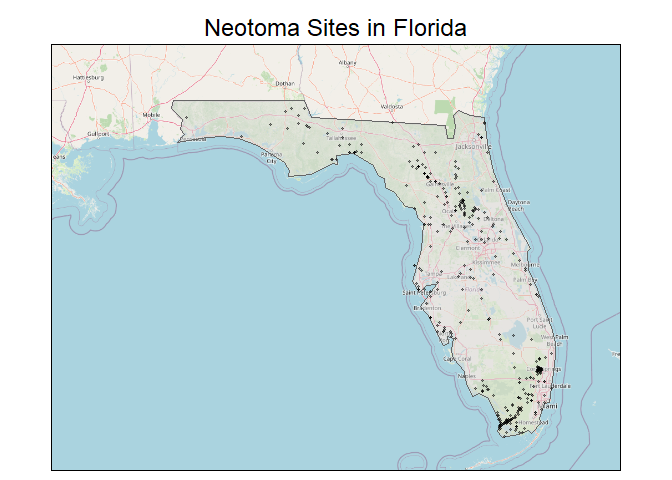

Below is a table of all the site names and descriptions of the area recorded by researchers who collected data from those sites.

| sitename | description |
| --- | --- |
| Barchampe Lake | Sinkhole pond. Physiography: Gulf Coastal Plain, level. Surrounding vegetation: pine/oak forest. |
| Camel Lake | Sinkhole lake. Physiography: level, Gulf Coastal Plain. Surrounding vegetation: Pinus palustris/Quercus laevis forest. |
| Site 13 (Delcourt et al. 1983) | Lake. |
| Site 14 (Delcourt et al. 1983) | Lake. |
| Site 66 (Delcourt et al. 1983) | Opening in woods. |
| Lake Hall | Sinkhole lake. Physiography: Gulf Coastal Plain, level. Surrounding vegetation: suburban, pine forest. |
| Mud Lake | Sinkhole lake. Upland vegetation i sand-pine (Pinus clausa) scrub, with a dense understory of sclerophyllous shrubs, including Quercus myrtifolia, Q. virginiana, Q. chapmanni, Q. margaretta, Carya flo… |
| Mud Lake stand C | Moss patch in sand pine (Pinus clausa) scrub. |
| Mud Lake stand D | Moss patch in southern broad-leaved forest. |
| Mud Lake stand E | Moss patch in southern broad-leaved forest, southeast corner of Mud Lake. Local damp patches with bayhead vegetation |

[output cut: 377 more lines]

## What kinds of data were recorded at these sites?

Now we know there are data concerning Florida held by Neotoma. The next question we might want to answer is what kinds of data these are.

| types | n |
| --- | --- |
| vertebrate fauna | 181 |
| pollen surface sample | 154 |
| diatom | 99 |
| water chemistry | 60 |
| pollen | 44 |
| loss-on-ignition | 5 |
| charcoal | 2 |
| X-ray fluorescence (XRF) | 1 |
| biomarker | 1 |
| geochemistry | 1 |

[output cut: 2 more lines]

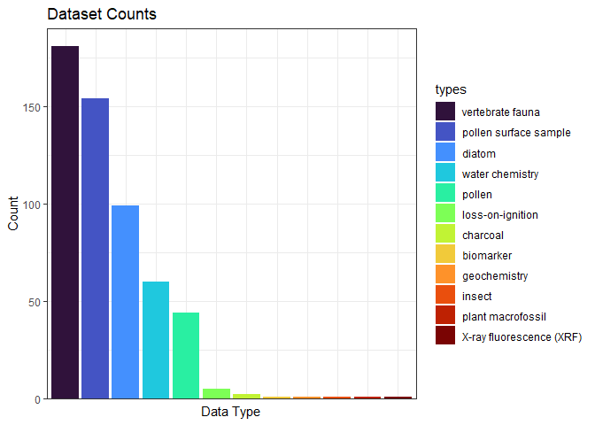

The most abundant datasets in Florida are vertebrate fauna.

Also abundant are:

- pollen surface samples,
- stratigraphic pollen (here labeled “pollen”: i.e., pollen sampled at different strata of a sedimentary core extracted from a lake),
- water chemistry data, and
- various kinds of diatom data.

Not abundant, but still interesting and potentially useful are:

- loss-on-ignition (i.e., how much of your mud can you burn away; a measure of reduced carbon content - potentially a proxy for eutrophication),
- sedimentary charcoal (for reconstructing fire history),
- X-ray fluorescence (for measuring trace elements),
- biomarkers (in this case, sedimentary concentrations of organic molecules used to reconstruct past temperature),
- geochemistry (in this case, trace metals in a sediment core measured mostly by ICP-MS),
- insects, and
- plant macrofossils.

The map below shows how these datasets are distributed.

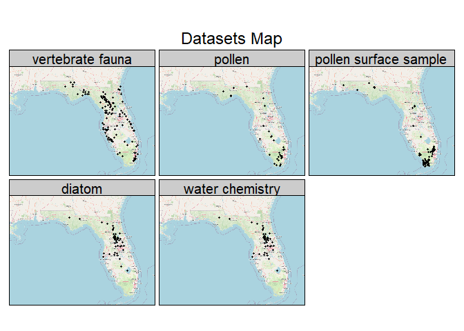

We can notice some overlaps in site location across these map panels.

Most strikingly, the diatom and water chemistry maps look the same. Many paleoecologists use sedimentary diatom assemblages as proxies for reconstructing changes in lake chemistry over time. In order to estimate changes in lake chemistry over time based on changes in diatom assemblage over time, these scientists have to gather information about what diatom assemblages at the surface of a lake (i.e., modern diatom assemblages) look like and their relationship to modern lake chemistries, across space. That is why these two dataset types are coextensive.

There are other overlaps too. It can be useful to have multiple proxies from the same site; their combination may paint a clearer picture of the past.

The Leaflet plots below enable dynamic exploration of maps for the most common dataset types: vertebrate fauna, diatoms, and pollen. Note that these are maps of sites, of which there may be fewer than the datasets counted and mapped above. Also note that the pollen map below shows sites from which both stratigraphic and surface pollen records were collected.

### Vertebrate Fauna Sites

[interactive chart not shown]

### Pollen Sites

[interactive chart not shown]

### Diatom Sites

[interactive chart not shown]

## Where, if anywhere, are the specimens held?

Some of the types of data held by Neotoma (e.g., pollen) tend not to be stewarded by institutional repositories. (Although particular researchers hold on to their pollen specimens - and those of their advisors, and their advisors’ advisors - for many years. I’ve seen pollen slides preserved since the 1950s. The individual pollen grains get fat from absorbing the fluid in which they are suspended!)

And some of these data (e.g., vertebrate fauna) are indeed held by museums or other institutions.

The following table shows which institutions are the largest holders of Floridian paleoecological specimens.

| repository | n |
| --- | --- |
| Missing | 460 |
| Florida Museum of Natural History | 92 |
| Academy of Natural Sciences, Philadelphia | 40 |
| University of Florida | 22 |
| Florida State Museum | 2 |
| American Museum of Natural History | 1 |
| National Museum of Natural History | 1 |
| University of South Florida | 1 |

Notice that the largest count (460) is for datasets without an institutional repository. The following table breaks down those data without a repository by dataset type.

[output not shown]

[output cut: 4 more lines]

As we might have suspected, these data without institutional repositories are pollen, other microfossils, and chemical data.

For those institutions which are the largest repositories of Floridian paleoecological specimens, what kinds of specimens are they holding?

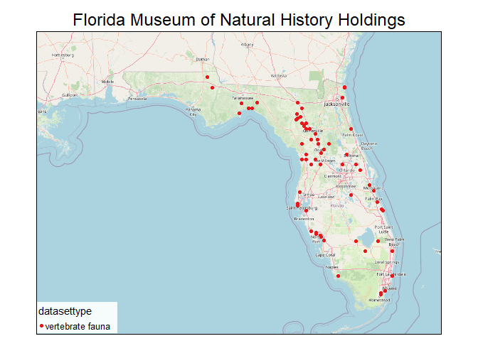

All the specimens at the Florida Museum of Natural History are vertebrate fauna.

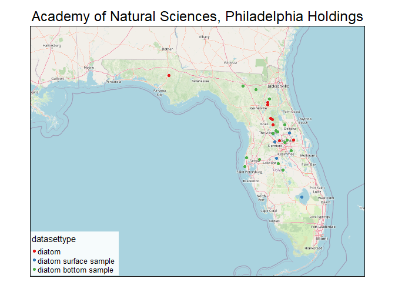

The Academy of Natural Sciences in Philadelphia actually holds diatom specimens - that surprises me!

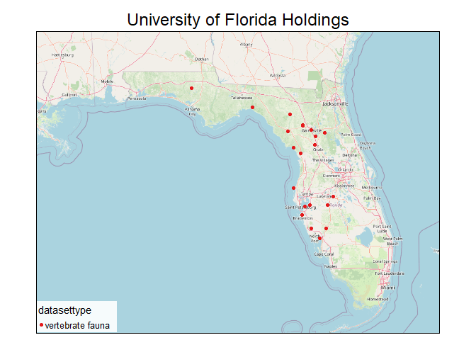

And the University of Florida, like its constituent museum, holds just vertebrate fauna.

## Querying for Contact Information

If we needed to, we could use Neotoma to query for contact information associated with the researchers who collected data from any particular site. That gets a little involved, so we won’t show the process here. Let us know if you would like to learn how to do that!

## Learning More

If you have any questions about the information presented here, if you would like to learn more about using Neotoma, or if you would like to join our Ethical Open Science Research Coordination Network for Past Global Change Data (EOS RCN), please reach out to Nick Hoffman at nicholashoffman@ucmerced.edu, or to the EOS RCN at EthicalOS.RCN@gmail.com.

Thank you for taking the time to read through this short presentation of Neotoma resources! We hope that it is helpful to you.